# Class 22: Assignment

John Doll

April 15, 2020

### Activity: Developing a good prediction model using CV

What variables are good predictors of how well you can predict the area covered by a forest fire? This activity is designed to have you bring together various aspects of model building (assumption checking, unusual observations, variable selection) along with cross-validation techniques to come up with a good predictive model for the above using available data.

Your goal is simple: **develop the best statistical model that you can for predicting the area covered by a forest fire.** The data is in the file `forestfires.csv`.

The following rules apply:

- You must read the accompanying document describing the data (it’s real data!) and the variables you have at your disposal.
- There are many fire events in the data set that were contained before spreading. These are indicated by having an `area` of 0. Remove these cases from the data set before you do any statistical work. (Your analysis will then be a conditional investigation of fire events that did involve spread.)
- You may use any or all variable selection methods at your disposal (forward stepwise, backward stepwise, best-subsets) to help guide you through model choices.
- **You must use 5-fold cross-validation as the method of testing any models you consider, and RMSE must be the criterion you use for comparing models.** *(We set the seed value for random partitioning into training and test data sets, so everyone should have the same partitioning in their cross-validation step.)*
- At the end of the Markdown document, you must:
  - indicate what the important predictors are
  - cite the RMSE (and provide supporting output) for your chosen model.

First, I will read in my data and filter area for any values of 0.

```r
fire <- read.csv("forestfires.csv")
fire <- fire %>%
  filter(area != 0)
glimpse(fire)
```

```
## Observations: 270
## Variables: 11
## $ month <fct> jul, sep, sep, aug, aug, jul, aug, aug, mar, sep, aug, sep, jun…
## $ day   <fct> tue, tue, mon, wed, fri, sat, wed, thu, mon, tue, tue, thu, fri…
## $ FFMC  <dbl> 85.8, 91.0, 90.9, 95.5, 90.1, 90.0, 95.5, 95.2, 90.1, 84.4, 94.…
## $ DMC   <dbl> 48.3, 129.5, 126.5, 99.9, 108.0, 51.3, 99.9, 131.7, 39.7, 73.4,…
## $ DC    <dbl> 313.4, 692.6, 686.5, 513.3, 529.8, 296.3, 513.3, 578.8, 86.6, 6…
## $ ISI   <dbl> 3.9, 7.0, 7.0, 13.2, 12.5, 8.7, 13.2, 10.4, 6.2, 3.2, 17.0, 17.…
## $ temp  <dbl> 18.0, 21.7, 21.9, 23.3, 21.2, 16.6, 23.8, 27.4, 13.2, 24.2, 17.…
## $ RH    <int> 42, 38, 39, 31, 51, 53, 32, 22, 40, 28, 43, 25, 39, 29, 43, 47,…
## $ wind  <dbl> 2.7, 2.2, 1.8, 4.5, 8.9, 5.4, 5.4, 4.0, 5.4, 3.6, 6.7, 4.5, 5.4…
## $ rain  <dbl> 0, 0, 0, 0, 0, 0, 0, 0, 0, 0, 0, 0, 0, 0, 0, 0, 0, 0, 0, 0, 0, …
## $ area  <dbl> 0.36, 0.43, 0.47, 0.55, 0.61, 0.71, 0.77, 0.90, 0.95, 0.96, 1.0…
```

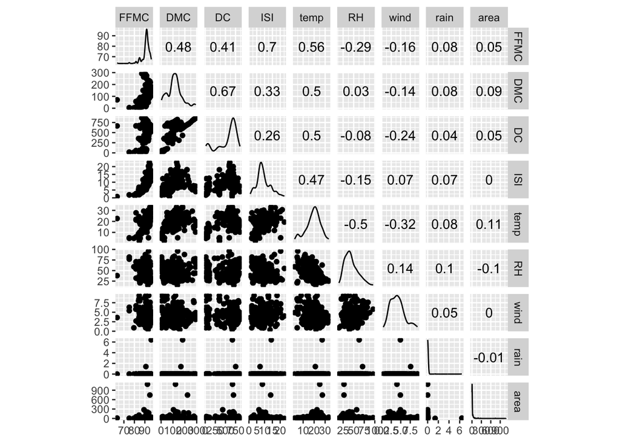

```r
ggscatmat(fire)
```

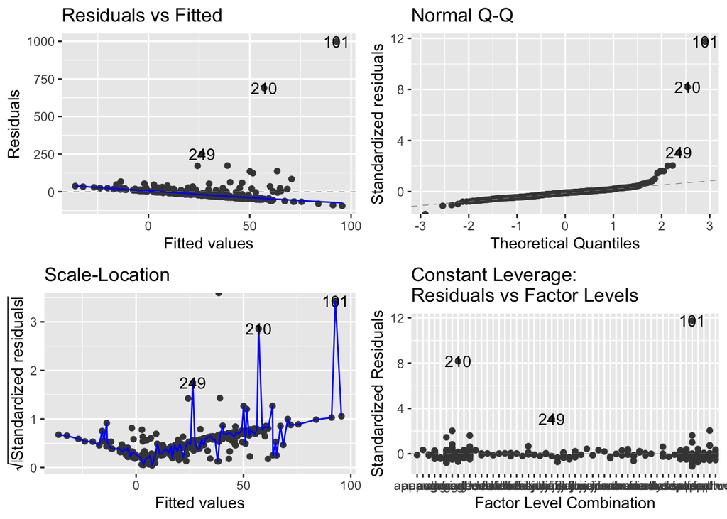

```r
fire.lm <- lm(area ~ month + day + FFMC + DMC + DC + ISI + temp + RH + wind + rain, data = fire)
autoplot(fire.lm)
```

Clearly the data has issues in every plot so I will do a boxcox to see if any transformation is recommended. The Residuals vs Fitted plot has a negative slope with points drifting upwards and away. The Normal Q-Q plot tails away at both ends of the line. The Scale - Location plot goes up and down crazy like mountains and valleys across the whole plot. The Residuals vs Factor Levels has several points above 3 standardized residuals away. Hopefully the boxcox has a solution.

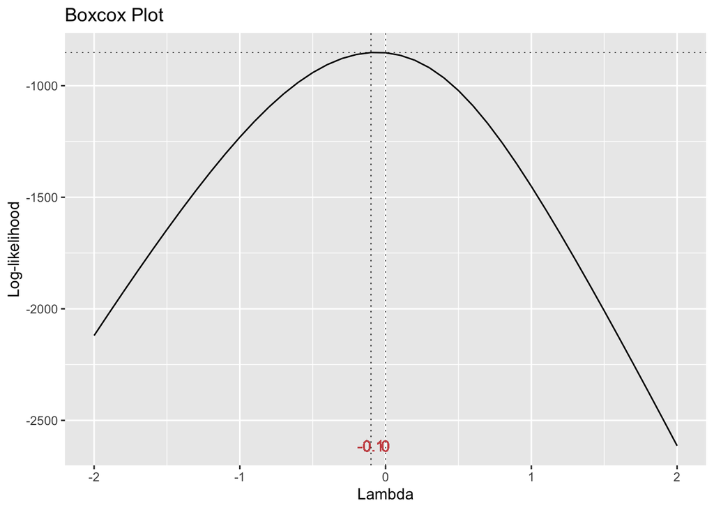

```r
gg_boxcox(fire.lm)
```

Thankfully the boxcox has a solution, and that’s to log the data, so that’s what we’ll do next.

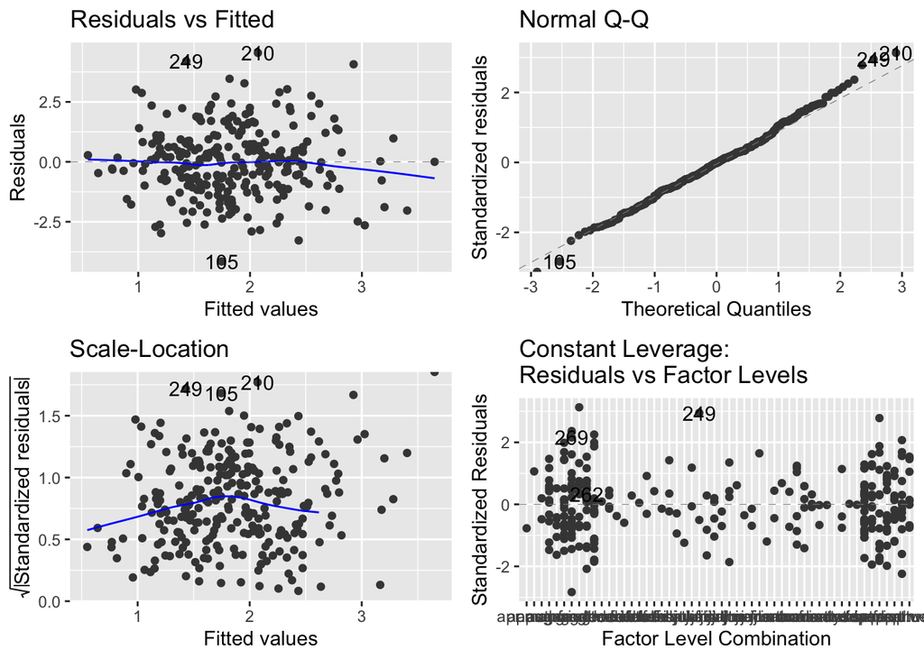

```r
fire.log <- lm(log(area) ~ month + day + FFMC + DMC + DC + ISI + temp + RH + wind + rain, data = fire)
autoplot(fire.log)
```

The log on the response variable made a world of difference and now our residual plots look much better. The Residuals vs Fitted plot is a mostly flat linear line that goes through the center with the data spread randomly about it. The Normal Q-Q plot looks normal. The Scale Location plot looks a million times better and the data is more random. The Residuals vs Factor Levels has most of its data inside the 3 standardized residuals range.

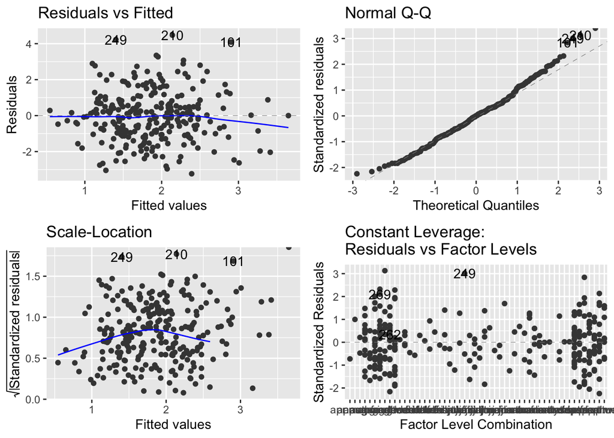

```r
fire.log2 <- lm(log(area) ~ month + day + FFMC + DMC + DC + ISI + temp + RH + wind + rain, data = fire[-105, -210, -249])
autoplot(fire.log2)
```

Here we see that removing those data points only makes other data points outliers so we will leave the data ponts in. Now it is time to analyze the condense the model.

```r
summary(fire.log)
```

```
##
## Call:
## lm(formula = log(area) ~ month + day + FFMC + DMC + DC + ISI +
##     temp + RH + wind + rain, data = fire)
##
## Residuals:
##     Min      1Q  Median      3Q     Max
## -4.1541 -0.9577 -0.0166  0.8238  4.5449
##
## Coefficients:
##              Estimate Std. Error t value Pr(>|t|)
## (Intercept)  1.146234   3.936945   0.291  0.77118
## monthaug     0.555056   1.354064   0.410  0.68222
## monthdec     1.630544   1.139817   1.431  0.15383
## monthfeb    -0.262877   0.911071  -0.289  0.77318
## monthjul    -0.050859   1.163873  -0.044  0.96518
## monthjun    -0.458362   1.097057  -0.418  0.67645
## monthmar    -0.438850   0.852415  -0.515  0.60713
## monthmay     1.367004   1.730040   0.790  0.43020
## monthoct     3.039641   1.651679   1.840  0.06692 .
## monthsep     1.803395   1.517000   1.189  0.23567
## daymon       0.008740   0.359090   0.024  0.98060
## daysat       0.626874   0.339913   1.844  0.06635 .
## daysun       0.393215   0.336016   1.170  0.24304
## daythu       0.222302   0.373847   0.595  0.55264
## daytue       0.339653   0.351397   0.967  0.33470
## daywed       0.008353   0.369771   0.023  0.98200
## FFMC         0.006587   0.043309   0.152  0.87924
## DMC          0.008981   0.002794   3.214  0.00148 **
## DC          -0.004732   0.002043  -2.316  0.02136 *
## ISI         -0.027846   0.037082  -0.751  0.45341
## temp         0.034965   0.034616   1.010  0.31345
## RH          -0.000700   0.009995  -0.070  0.94422
## wind         0.056192   0.058279   0.964  0.33590
## rain         0.057647   0.241393   0.239  0.81145
## ---
## Signif. codes:  0 '***' 0.001 '**' 0.01 '*' 0.05 '.' 0.1 ' ' 1
##
## Residual standard error: 1.497 on 246 degrees of freedom
## Multiple R-squared:  0.1203, Adjusted R-squared:  0.03803
## F-statistic: 1.462 on 23 and 246 DF,  p-value: 0.08377
```

```r
fire <- fire %>%
  mutate(month = factor(month, levels = c("jan", "feb", "mar", "apr", "may", "jun", "jul", "aug", "sep", "oct",     "nov", "dec")),
         day = factor(day, levels = c("sun", "mon", "tue", "wed", "thu", "fri", "sat")))
step.backwards <- step(fire.log, direction = "backward")
```

```
## Start:  AIC=240.88
## log(area) ~ month + day + FFMC + DMC + DC + ISI + temp + RH +
##     wind + rain
##
##         Df Sum of Sq    RSS    AIC
## - day    6    13.254 564.84 235.29
## - RH     1     0.011 551.59 238.88
## - FFMC   1     0.052 551.63 238.90
## - rain   1     0.128 551.71 238.94
## - ISI    1     1.264 552.85 239.50
## - wind   1     2.084 553.67 239.90
## - temp   1     2.288 553.87 240.00
## <none>               551.58 240.88
## - month  9    40.384 591.96 241.96
## - DC     1    12.031 563.61 244.71
## - DMC    1    23.163 574.74 249.99
##
## Step:  AIC=235.29
## log(area) ~ month + FFMC + DMC + DC + ISI + temp + RH + wind +
##     rain
##
##         Df Sum of Sq    RSS    AIC
## - RH     1     0.046 564.88 233.31
## - rain   1     0.087 564.92 233.33
## - FFMC   1     0.123 564.96 233.35
## - ISI    1     2.174 567.01 234.33
## - wind   1     2.249 567.08 234.36
## - temp   1     3.876 568.71 235.14
## <none>               564.84 235.29
## - month  9    40.220 605.06 235.86
## - DC     1    13.818 578.65 239.82
## - DMC    1    25.429 590.26 245.18
##
## Step:  AIC=233.31
## log(area) ~ month + FFMC + DMC + DC + ISI + temp + wind + rain
##
##         Df Sum of Sq    RSS    AIC
## - FFMC   1     0.098 564.98 231.36
## - rain   1     0.123 565.00 231.37
## - ISI    1     2.137 567.02 232.33
```

[output cut: 37 more lines]

```
## <none>               567.36 228.49
## - temp   1     5.881 573.24 229.28
## - month  9    46.770 614.13 231.88
## - DC     1    13.260 580.62 232.73
## - DMC    1    29.184 596.54 240.03
##
## Step:  AIC=227.22
## log(area) ~ month + DMC + DC + temp
##
##         Df Sum of Sq    RSS    AIC
## <none>               568.89 227.22
## - temp   1     5.034 573.93 227.60
## - DC     1    12.462 581.35 231.07
## - month  9    53.755 622.65 233.60
## - DMC    1    28.953 597.85 238.63
```

Here, after doing the backwards model, we get down to a nice 4 variable model. The backwards model is dependent on `month`, `DMC`, `DC`, and `temp`. We will now run a forwards selection to see how similar they are.

```r
null.fit <- lm(log(area) ~ 1, data = fire)
step.forwards <- step(null.fit, scope = formula(fire.log), direction = "forward")
```

```
## Start:  AIC=229.48
## log(area) ~ 1
##
##         Df Sum of Sq    RSS    AIC
## + ISI    1    7.6217 619.38 228.18
## <none>               627.00 229.48
## + wind   1    1.8726 625.13 230.67
## + RH     1    1.5477 625.45 230.81
## + FFMC   1    1.2942 625.70 230.92
## + temp   1    0.7464 626.25 231.16
## + DMC    1    0.5452 626.45 231.25
## + DC     1    0.5299 626.47 231.25
## + rain   1    0.0878 626.91 231.44
## + day    6   14.4539 612.54 235.18
## + month  9   23.5910 603.41 237.13
##
## Step:  AIC=228.18
## log(area) ~ ISI
##
##         Df Sum of Sq    RSS    AIC
## <none>               619.38 228.18
## + DMC    1    3.0487 616.33 228.85
## + RH     1    2.8007 616.58 228.96
## + wind   1    2.4749 616.90 229.10
## + FFMC   1    1.2898 618.09 229.62
## + rain   1    0.2332 619.14 230.08
## + temp   1    0.2282 619.15 230.08
## + DC     1    0.0004 619.38 230.18
## + day    6   12.9827 606.39 234.46
## + month  9   16.4571 602.92 238.91
```

So the forwards and backwards models are not similar at all. The forwards model only contains the variable `ISI` which is not even in the backwards model, so we have more model exploring to do. I will now split my data so that I can use 80% to make a model and the other 20% as my data to see how well my forwards, backwards, and full model compare.

```r
trainIndex <- createDataPartition(fire$area, p=0.8, list=FALSE)
head(trainIndex)
```

```
##      Resample1
## [1,]         1
## [2,]         2
## [3,]         3
## [4,]         4
## [5,]         6
## [6,]         8
```

```r
train.data <- fire %>%
  filter(row_number() %in% trainIndex)
test.data <- fire %>%
  filter(!row_number() %in% trainIndex) %>%
  mutate(area = as.double(log(area)))
train.fit <- lm(log(area) ~ DMC + month + DC + temp, data=train.data)
test.pred <- predict(train.fit, newdata=test.data)
error <- sqrt( mean((test.data$area - test.pred)^2) )   # Calculation of RMSE
error
```

```
## [1] 1.333522
```

```r
train.fit2 <- lm(log(area) ~ ISI, data=train.data)
test.pred2 <- predict(train.fit2, newdata=test.data)
error2 <- sqrt( mean((test.data$area - test.pred2)^2) )   # Calculation of RMSE
error2
```

```
## [1] 1.309981
```

```r
train.fit3 <- lm(log(area) ~ month + day + FFMC + DMC + DC + ISI + temp + RH + wind + rain, data=train.data)
test.pred3 <- predict(train.fit3, newdata=test.data)
error3 <- sqrt( mean((test.data$area - test.pred3)^2) )   # Calculation of RMSE
error3
```

```
## [1] 1.331321
```

Looking initially at this data output, we see that the RSME’s are all very close, but the second model has a partially better value of 1.309. So at this point, the model with just `ISI` is our best model. Now we will run a 5 fold cross validation for all the models.

```r
train_control <- trainControl(method="cv", number=5)
model1 <- train(log(area) ~ DMC + DC + month + temp, data=fire, trControl=train_control, method="lm")
model2 <- train(log(area) ~ ISI, data = fire, trControl = train_control, method="lm")
model3 <- train(log(area) ~ DMC + month + DC + temp + FFMC + month + day + temp + RH + rain, data = fire, trControl = train_control, method="lm")
results <- resamples(list(Mod1 = model1, Mod2 = model2, Mod3 = model3))
summary(results)
```

```
##
## Call:
## summary.resamples(object = results)
##
## Models: Mod1, Mod2, Mod3
## Number of resamples: 5
##
## MAE
##          Min.  1st Qu.   Median     Mean  3rd Qu.     Max. NA's
## Mod1 1.042383 1.044690 1.216750 1.178107 1.250809 1.335903    0
## Mod2 1.120442 1.125480 1.178635 1.200266 1.242258 1.334514    0
## Mod3 1.054349 1.158056 1.178677 1.196125 1.246726 1.342815    0
##
## RMSE
##          Min.  1st Qu.   Median     Mean  3rd Qu.     Max. NA's
## Mod1 1.340944 1.396344 1.515835 1.498576 1.562912 1.676846    0
## Mod2 1.407743 1.416472 1.426903 1.519627 1.601565 1.745451    0
## Mod3 1.292117 1.464356 1.517083 1.519050 1.575022 1.746672    0
##
## Rsquared
##              Min.     1st Qu.      Median       Mean    3rd Qu.      Max. NA's
## Mod1 1.035617e-02 0.012193502 0.063705379 0.05542203 0.06480856 0.1260465    0
## Mod2 7.231097e-06 0.006269072 0.008614845 0.03149850 0.03884080 0.1037606    0
## Mod3 9.414457e-06 0.004929867 0.075132980 0.05624596 0.08458998 0.1165675    0
```

The smallest RSME value belongs to the first model which is our backwards selection model. It also has the smallest max RSME and second smallest min RSME. I’ll plot the data to get a better look at it.

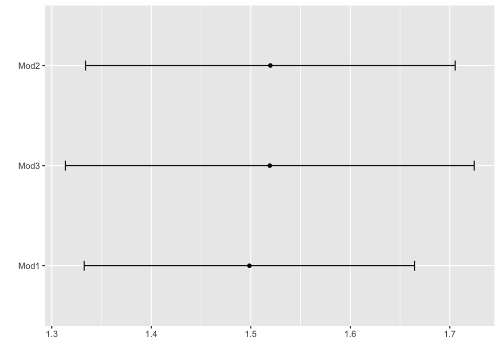

```r
ggplot(results, metric="RMSE")
```

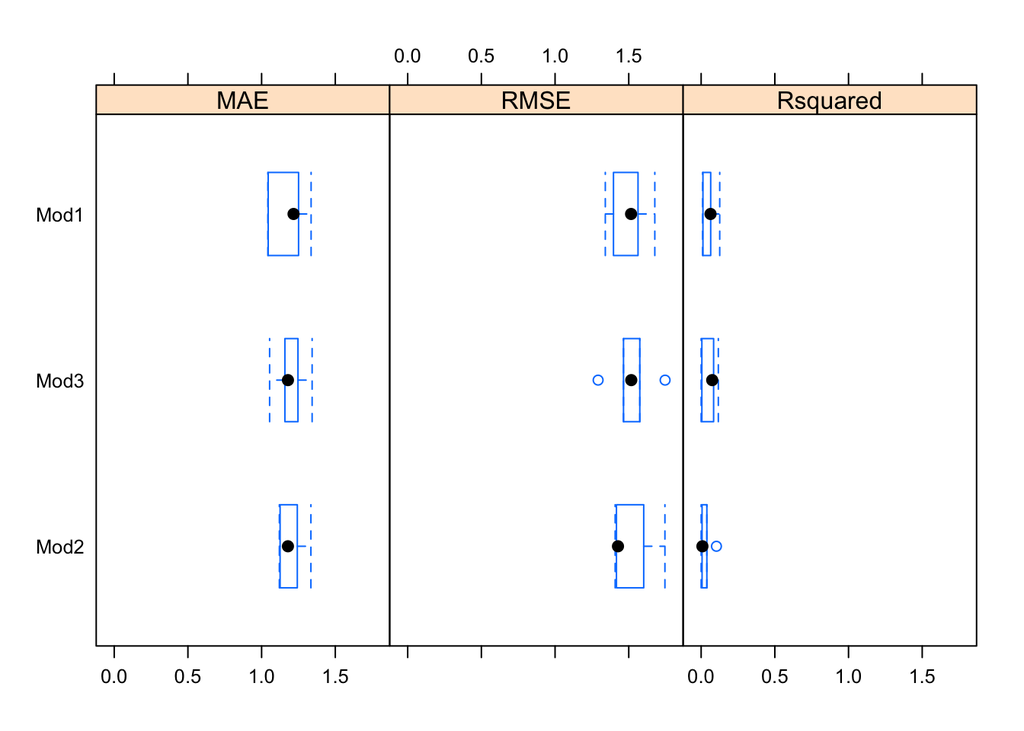

```r
bwplot(results)
```

All models are very close. We can see from the ggplot that the first model has the smallest range, and lowest mean RSME. This will be the model we choose since these graphs and outputs support my model. My important variables are `DMC`, `DC`, `month`, and `temp`. I will run a summary of my data for further proof.

```r
summary(step.backwards)
```

```
##
## Call:
## lm(formula = log(area) ~ month + DMC + DC + temp, data = fire)
##
## Residuals:
##     Min      1Q  Median      3Q     Max
## -4.0282 -0.9929 -0.0772  0.8060  4.5184
##
## Coefficients:
##              Estimate Std. Error t value Pr(>|t|)
## (Intercept)  1.811315   0.502786   3.603 0.000378 ***
## monthmar    -0.222897   0.597042  -0.373 0.709206
## monthapr     0.269138   0.880843   0.306 0.760198
## monthmay     1.343751   1.577514   0.852 0.395109
## monthjun    -0.397359   0.884761  -0.449 0.653728
## monthjul     0.076791   0.953527   0.081 0.935875
## monthaug     0.592080   1.163300   0.509 0.611212
## monthsep     1.862490   1.354971   1.375 0.170465
## monthoct     3.083355   1.498251   2.058 0.040602 *
## monthdec     1.936787   0.919750   2.106 0.036194 *
## DMC          0.009612   0.002658   3.617 0.000359 ***
## DC          -0.004743   0.001999  -2.373 0.018395 *
## temp         0.033362   0.022122   1.508 0.132772
## ---
## Signif. codes:  0 '***' 0.001 '**' 0.01 '*' 0.05 '.' 0.1 ' ' 1
##
## Residual standard error: 1.488 on 257 degrees of freedom
## Multiple R-squared:  0.09267,    Adjusted R-squared:  0.05031
## F-statistic: 2.187 on 12 and 257 DF,  p-value: 0.01273
```